# Struktur Data

Struktur data merupakan cara programmer untuk merepresentasikan suatu data, dan memudahkan programmer untuk menyelesaikan permasalahan dengan menggunakan struktur data tersebut.

Struktur data Linear Structure merupakan struktur data sederhana dimana ketika data ditambahkan maka data tersebut berada pada posisi relatif terhadap data yang lain dari struktur data tersebut. Linear structure ini memiliki dua buah ujung. Dua buah ujung ini memiliki beberapa istilah seperti left-right, front-rear, ataupun top-bottom. Terdapat beberapa struktur data yang termasuk pada linear structure ini, yaitu :

- Stacks
- Queues
- Lists

Ketiga jenis struktur data tersebut berbeda dalam penambahan atau penghapusan suatu data. Misalkan, suatu struktur data hanya diperbolehkan menghapus data pada salah satu ujung, sedangkan pada struktur data lain, penghapusan data dapat dilakukan pada kedua ujung. Struktur data yang akan dibahas pertama kali adalah Stacks, yang terdiri dari :

# Definisi Stacks

Stacks adalah satu struktur data dimana penambahan dan penghapusan data, hanya dapat dilakukan pada satu ujung yang sama, atau yang biasa dikenal dengan istilah top.

Semakin data jauh berada dari posisi top, maka data tersebut diindikasikan berada di stack lebih lama dibandingkan dengan data yang berada dekat pada data di posisi top.

Jika terdapat data baru yang ditambahkan di stack, maka data ini pulalah yang akan dihapus ketika terdapat proses penghapusan data. Konsep ini dikenal dengan nama LIFO-Last In First Out.

Konsep stack ini dapat ditemui pada permasalahan sehari-hari, misalkan tumpukan buku pada Gambar 1 berikut.

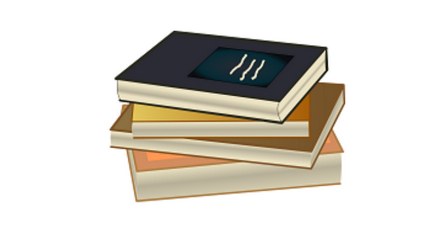

Jika kita ingin mengambil buku pada tumpukan buku tersebut, maka buku yang dapat kita ambil adalah buku yang berada di posisi teratas. Jika ingin mengambil buku yang berada di posisi paling bawah, maka kita harus mengambil buku-buku yang berada di posisi atasnya terlebih dahulu. Begitu juga ketika terdapat penambahan buku baru, maka buku baru ini akan berada di posisi paling atas.

# Operasi pada Stacks

Terdapat operasi dasar pada Stacks,

- stack (), inisialisasi stack yang kosong
- push(data), penambahan data baru pada posisi top dari stack
- pop(), penghapusan data yang terdapat di posisi top dari stack. R eturn value dari fungsi ini adalah data yang dihapus dari stack tersebut
- peek(), informasi data yang terletak pada posisi top
- isEmpty(), untuk memeriksa apakah stack dalam keadaan kosong
- size(), informasi jumlah data yang terdapat pada stack

Ilustrasi proses penambahan data atau yang dikenal dengan istilah push dapat dilihat pada Gambar 2 berikut.

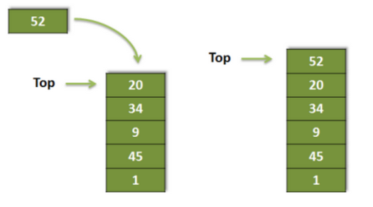

**Gambar 2. Operasi push pada Stacks**

Sedangkan proses penghapusan data atau yang dikenal dengan istilah pop dapat dilihat pada Gambar 3 berikut.

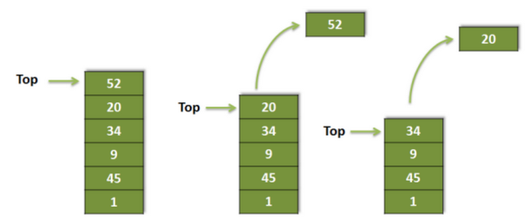

**Gambar 3. Operasi pop pada Stacks**

## Code

Berikut adalah fungsi-fungsi yang dibutuhkan untuk mengimplementasikan stacks.

```python
def stack():
    s=[]
    return (s)
def push(s,data):
    s.append(data)
def pop(s):
    data=s.pop()
    return(data)
def peek(s):
    return(s[len(s)-1])
def isEmpty(s):
    return (s==[])
def size(s):
    return(len(s))
```

Berikut adalah contoh penggunaan fungsi-fungsi stacks yang telah dibuat

```python
import Stack as st

data=st.stack()
st.isEmpty(data)

st.push(data,100)
st.push(data,23)
st.push(data,34)
st.pop(data)
st.push(data,56)
st.pop(data)
print(data)
```

[output not shown]

### Konversi Bilangan

Pada dunia ilmu komputer seringkali dibutuhkan proses konversi dari suatu bilangan ke bilangan lain, misalkan dari bilangan desimal menjadi bilangan biner atau menjadi bilangan octal. Ilustrasi proses konversi dari bilangan desimal ke bilangan biner dapat dilihat pada Gambar 4 berikut.

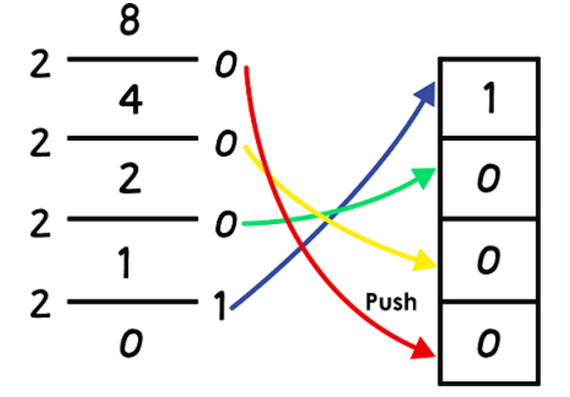

**Gambar 4. Konversi bilangan desimal ke biner**  
Dari Gambar tersebut dapat dilihat bahwa bilangan biner didapatkan dari sisa pembagian bilangan desimal dengan dua. Hasil konversi didapatkan dengan cara membaca terbalik semua sisa tersebut.

```python
#Manual Tanpa Function atau Class
stackkk=[]

stackkk.append('A')
stackkk.append('L')
stackkk.append('D')
stackkk.append('O')
print(stackkk)

elemen_akhir = stackkk[-1]

hapus_elemen = stackkk.pop()
print(stackkk)
```

```
['A', 'L', 'D', 'O']
['A', 'L', 'D']
```

```python
#Stack dengan menggunakan def/Function
def stack():
    s=[]
    return (s)
def push(s,data):
    s.append(data)
def pop(s):
    data=s.pop()
    return(data)
def peek(s):
    return(s[len(s)-1])
def isEmpty(s):
    return (s==[])
def size(s):
    return(len(s))

s=[]

push(s,100)
pop(s)
push(s,200)
pop(s)
push(s,'A')
push(s,'L')
push(s,'D')
push(s,'O')
peek(s)
```

```
'O'
```

```python
kata = 'KATAK'
A = []
B = []

def pushh(s, objek):
    for i in range(len(objek)):
        s.append(objek[i])
    print(s)

def pushh2(s, objek):
    for j in range(len(objek),0,-1):
        s.append(objek[j-1])
    print(s)

def cekKata(a,b):
    return a==b

pushh(A, kata)
pushh2(B, kata)
print(cekKata(A,B))
```

```
['K', 'A', 'T', 'A', 'K']
['K', 'A', 'T', 'A', 'K']
True
```

### Latihan - 1

Buat function untuk 'reverse word' dengan menggunakan konsep stacks, misalkan kata 'stacks' menjadi 'skcats'

```python
def reverseWord(word):
    dataStack=stack()
    for ch in word:
        push(dataStack,ch)
    temp=''
    while not(isEmpty(dataStack)):
        temp=temp+pop(dataStack)
    return temp

reverseWord('aku')
```

```
'uka'
```

### Implementasi Stacks

Berikut adalah contoh implementasi untuk penggunaan stacks, yaitu delimiter matching dan konversi desimal ke biner

### Delimiter Matching

Parentheses sering digunakan untuk urutan penyelesaian dalam persamaan Matematika, seperti contoh berikut:  
P = 5 x (4 + 5) / ((3 + 2) x (10 - 8))  
Dengan penggunaan parentheses maka persamaan tersebut dapat diselesaikan secara benar, hanya saja terkadang parentheses yang ditulis tidak lengkap, sehingga hasil persamaan tidak dapat dikerjakan atau tidak sesuai dengan yang diinginkan, seperti contoh berikut :  
P = 5 x (4 + 5) / ((3 + 2) x (10 - 8)  
Oleh karena itu diperlukan algoritma untuk pemeriksaan parentheses ini atau secara umum delimiter, yaitu '{ }', '[ ]', dan '( )'.  
Beberapa tahapan atau algoritma untuk pengecekan parentheses ini adalah :

1. Baca setiap karakter yang terdapat pada suatu string matematika
2. Jika karakter adalah kurung buka, maka masukkan dalam stack
3. Jika karakter adalah kurung tutup, ada beberapa kondisi yang harus diperiksa, yaitu :
- Jika stack dalam keadaan empty, maka jumlah kurung tutup lebih banyak daripada kurung buku
- Jika stack dalam keadaan tidak empty, maka maka pop stack, dan cocokkan karakter hasil pop dengan kurung tutup, jika sejenis, maka matched, jika tidak maka jenis kurung tidak sama
4. Jika semua karakter telah terbaca, dan stack masih dalam keadaan terisi (tidak empty), maka jumlah kurung buka lebih banyak daripada kurung tutup

```python
def checkParentheses(strMat):
    data= stack()
    for ch in strMat:
        if ch=='(':
            push(data,ch)
        elif ch==')':
            if stack.isEmpty(data):
                return 'kelebihan kurung tutup'
            else:
                stack.pop(data)
        if isEmpty(data):
            return True
        else:
            return 'Kelebihan kurung buka'
```

```python
checkParentheses('5 x (4 + 5) / (3 + 2) x (10 - 8))')
```

```
True
```

```python
a='5 x (4 + 5) / (3 + 2) x (10 - 8))'
'300' in a
```

```
False
```

```python
# binary
def convertBinary(num):
    temp=stack()
    divNum=num
    while divNum>0:
        push(temp,divNum%2)
        divNum=divNum//2
    tempStr=''
    for i in range(size(temp)):
        tempStr=tempStr+str(pop(temp))
    return tempStr

print(convertBinary(25))
```

```
11001
```

```python
stack = []
while True:
    teks = input('Masukkan Kata = ')

    if teks.upper() == 'UNDO':
        if stack:
            stack.pop()
            print('Berhasil melakukan UNDO')
        else:
            print('tidak kata yang di UNDO')
            break
    else:
        stack.append(teks)

    if stack:
        print('output = ',stack [-1])
    else:
        print('output kosong')
```

```
output =  aldo
output =  iqbal
Berhasil melakukan UNDO
output =  aldo
Berhasil melakukan UNDO
output kosong
tidak kata yang di UNDO
```

```python
kalimat = input("Masukkan kalimat: ")
kata = kalimat.split()          # Memisahkan kata
kata_terbalik = kata[::-1]      # Membalik urutan kata
hasil = " ".join(kata_terbalik) # Menggabungkan kembali

print('Input = ',kalimat)
print('Output = ',hasil)
```

```
Input =  minum air dan makan nasi
Output =  nasi makan dan air minum
```

```python
stack = []
panjang_data= 0

stack.append(10)
stack.append(50)
stack.append(30)
stack.append(90)
stack.append(30)

for i in stack:
    panjang_data+=1
print('jumlah elemen dalam stack = ',panjang_data)
```

```
jumlah elemen dalam stack =  5
```

```python
stack = []

stack.append(10)
stack.append(20)
stack.append(30)
stack.append(40)
stack.append(50)

print(stack)

stack.pop()
stack.pop()
stack.pop()
stack.append(40)
stack.append(50)

print(stack)
```

```
[10, 20, 30, 40, 50]
[10, 20, 40, 50]
```

```python
kata = input('masukkan kata = ')
stack = []
revers = []

def push(s, objek):
    for i in range(len(objek)):
        s.append(objek[i])
    print(s)

def push2(s, objek):
    for j in range(len(objek),0,-1):
        s.append(objek[j-1])
    print(s)

push(stack,kata)
push2(revers,kata)
```

```
['k', 'a', 's', 'u', 'r', ' ', 'r', 'u', 's', 'a', 'k']
['k', 'a', 's', 'u', 'r', ' ', 'r', 'u', 's', 'a', 'k']
```